# PSY221A_Project-QuartoDocument

Author

Claire Anderson

## Hypothesis 1

H1: Categorical IV - Continuous DV

Individuals with higher educational attainment will have more progressive (less traditional) gender role attitudes.

Educational attainment – The highest level of formal education reported for the respondent (cot_educ)

Gender equality attitudes – Attitudes about gender roles in household labor and decision-making. The three items express traditional, unequal roles (Gender_Equality_1–Gender_Equality_3)

### Variables and descriptive statistics

- **Educational attainment (`cot_educ`):** A categorical variable with 7 groups: 1=None; 2=Primary; 3=Secondary; 4=High school/technical college; 5=Bachelor; 6=Master; 7=PhD/MD/JD or equivalent.
- **Gender equality attitudes (`geneqavg`):** Gender equality attitudes: Mean of three reverse coded items on attitudes about gender roles in household labor and decision-making; all three responses required. The three items express traditional, unequal roles, each. 1=Definitely disagree; 7=Definitely agree. Codes 2–6 are intermediate response categories. Values were reverse coded so higher values = greater gender equality endorsement.

```r
# Count respondents in each group.
table(h1Data$cot_educ)
```

```
                         None                       Primary
                          264                           464
                    Secondary High school/technical college
                         5168                         19416
                     Bachelor                        Master
                        38558                         17885
      PhD/MD/JD or equivalent
                         5405
```

```r
# Summarize gender equality points (greater score=more positive attitude towards gender equality) separately for each group.
by(h1Data$geneqavg, h1Data$cot_educ, summary)
```

```
h1Data$cot_educ: None
   Min. 1st Qu.  Median    Mean 3rd Qu.    Max.
  1.000   3.000   4.000   4.375   6.083   7.000
------------------------------------------------------------
h1Data$cot_educ: Primary
   Min. 1st Qu.  Median    Mean 3rd Qu.    Max.
  1.000   3.333   4.667   4.540   6.000   7.000
------------------------------------------------------------
h1Data$cot_educ: Secondary
   Min. 1st Qu.  Median    Mean 3rd Qu.    Max.
  1.000   4.000   5.667   5.280   7.000   7.000
------------------------------------------------------------
h1Data$cot_educ: High school/technical college
   Min. 1st Qu.  Median    Mean 3rd Qu.    Max.
  1.000   4.667   6.000   5.663   7.000   7.000
------------------------------------------------------------
h1Data$cot_educ: Bachelor
   Min. 1st Qu.  Median    Mean 3rd Qu.    Max.
  1.000   5.333   6.667   5.937   7.000   7.000
------------------------------------------------------------
h1Data$cot_educ: Master
   Min. 1st Qu.  Median    Mean 3rd Qu.    Max.
  1.000   5.000   6.667   5.904   7.000   7.000
------------------------------------------------------------
h1Data$cot_educ: PhD/MD/JD or equivalent
   Min. 1st Qu.  Median    Mean 3rd Qu.    Max.
  1.000   5.000   6.667   5.792   7.000   7.000
```

### Graph

Figure 1 shows the distribution of points by educational attainment. The half-violin shows the shape of the distribution, the box summarizes the median and quartiles, and the dots represent individual responses.

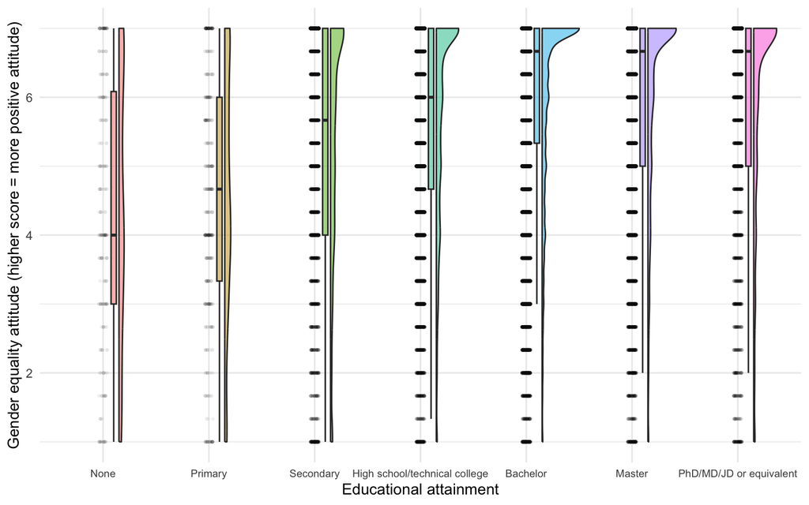

Figure 1: Points allocated to gender equality attitude, by educational attainment.

```r
ggplot(h1Data, aes(x = cot_educ, y = geneqavg,
                   fill = cot_educ)) +
  geom_rain(alpha = 0.5, point.args = list(alpha = 0.04, size = 0.6)) +
  labs(x = "Educational attainment", y = "Gender equality attitude (higher score = more positive attitude)") +
  theme_minimal() +
  theme(legend.position = "none",
        axis.text.x = element_text(size=7.5))
```

## Hypothesis 2

H2: Continuous-composite IV - Continuous DV Higher confidence in relationships will be correlated with lower reported importance of looking attractive. Commitment in romantic love (Love_11–Love_15) ; Importance of looking attractive (Attract_importance_1)

### Variables and descriptive statistics

“Importance of looking attractive: 1=Not at all important to 9=Extremely important.”

- **Relationship commitment (`commitmentavg`):** The mean of `Love_11`, `Love_12`, `Love_13`, `Love_14`, and `Love_15`, each rated 1=Not at all to 5=Extremely. No reverse coding; all five responses are required. Higher scores indicate greater commitment.

Love_11: I have confidence in the stability of my relationship with my partner. ; Love_12: I view my commitment to my partner as a solid one. ; Love_13: I am certain of my love for my partner. ; Love_14: I view my relationship with my partner as permanent. ; Love_15: I feel a sense of responsibility toward my partner.

This dataset includes respondents who were dating, in a committed relationship, or married.

- **Importance of looking attractive (`attractimp`):** A single item about the importance of looking attractive. Responses range from 1 (Not at all important) to 9 (Extremely important).

```r
summary(h2Data[, c("commitmentavg", "attractimp")])
```

```
 commitmentavg     attractimp
 Min.   :1.000   Min.   :1.000
 1st Qu.:3.800   1st Qu.:6.000
 Median :4.600   Median :7.000
 Mean   :4.234   Mean   :6.719
 3rd Qu.:5.000   3rd Qu.:8.000
 Max.   :5.000   Max.   :9.000
```

### Graph

Figure 2 shows the relationship between relationship commitment and importance of looking attractive. Points are jittered to make overlapping responses easier to see; the recorded scores are unchanged. The line summarizes the linear trend.

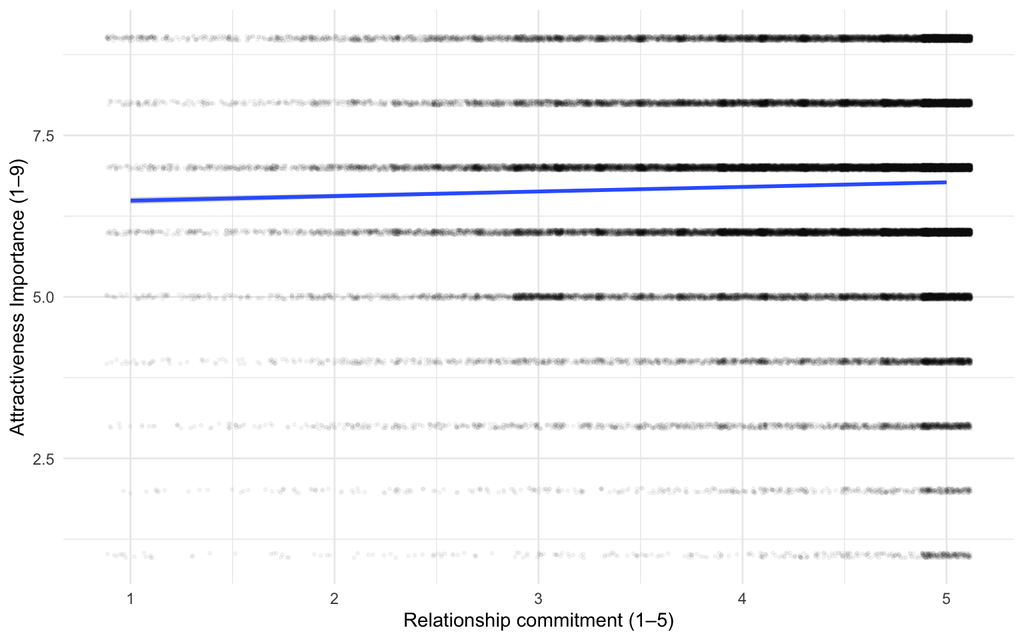

Figure 2: Relationship commitment and importance of looking attractive

```r
ggplot(h2Data, aes(x = commitmentavg, y = attractimp)) +
  geom_jitter(width = .12, height = .04, alpha = .04, size = .6) +
  geom_smooth(method = "lm") +
  labs(x = "Relationship commitment (1–5)",
       y = "Attractiveness Importance (1–9)") +
  theme_minimal()
```

### Observed trend

```r
r <- cor(h2Data$commitmentavg, h2Data$attractimp, use = "complete.obs")
round(r, 2)
```

```
[1] 0.04
```

The correlation was 0.04, indicating a very weak positive association. Respondents who reported higher relationship commitment tended to report greater importance of personally looking attractive.